# EDA to House Price Advanced Regression house_price.csv Data

Dhyka

11/28/2021

```r
library(ggplot2)
library(dplyr)
library(ggcorrplot)
```

```r
dfori = read.csv('house_price.csv') # Sesuaikan dengan nama file house price di laptop masing-masing
glimpse(dfori)
```

```
## Rows: 1,460
## Columns: 81
## $ Id            <int> 1, 2, 3, 4, 5, 6, 7, 8, 9, 10, 11, 12, 13, 14, 15, 16, 1~
## $ MSSubClass    <int> 60, 20, 60, 70, 60, 50, 20, 60, 50, 190, 20, 60, 20, 20,~
## $ MSZoning      <chr> "RL", "RL", "RL", "RL", "RL", "RL", "RL", "RL", "RM", "R~
## $ LotFrontage   <int> 65, 80, 68, 60, 84, 85, 75, NA, 51, 50, 70, 85, NA, 91, ~
## $ LotArea       <int> 8450, 9600, 11250, 9550, 14260, 14115, 10084, 10382, 612~
## $ Street        <chr> "Pave", "Pave", "Pave", "Pave", "Pave", "Pave", "Pave", ~
## $ Alley         <chr> NA, NA, NA, NA, NA, NA, NA, NA, NA, NA, NA, NA, NA, NA, ~
## $ LotShape      <chr> "Reg", "Reg", "IR1", "IR1", "IR1", "IR1", "Reg", "IR1", ~
## $ LandContour   <chr> "Lvl", "Lvl", "Lvl", "Lvl", "Lvl", "Lvl", "Lvl", "Lvl", ~
## $ Utilities     <chr> "AllPub", "AllPub", "AllPub", "AllPub", "AllPub", "AllPu~
## $ LotConfig     <chr> "Inside", "FR2", "Inside", "Corner", "FR2", "Inside", "I~
## $ LandSlope     <chr> "Gtl", "Gtl", "Gtl", "Gtl", "Gtl", "Gtl", "Gtl", "Gtl", ~
## $ Neighborhood  <chr> "CollgCr", "Veenker", "CollgCr", "Crawfor", "NoRidge", "~
```

[output cut: 68 more lines]

# 1. Start with the target

Lakukan analisis univariat terhadap variabel target, yakni SalePrice dan deskripsikan apa saja insight yang bisa didapat. # Jawab :

Pertama-tama, saya akan mencari profil dasar dari variabel SalePrice

```r
dfori %>%
  select(SalePrice) %>%
  summary()
```

```
##    SalePrice
##  Min.   : 34900
##  1st Qu.:129975
##  Median :163000
##  Mean   :180921
##  3rd Qu.:214000
##  Max.   :755000
```

Setelah itu kita coba melihat apakah pada kolom SalePrice terdapat missing value

```r
dfori['SalePrice'] %>% is.na() %>% colSums()
```

```
## SalePrice
##         0
```

Dari analisa diatas kita bisa mengambil insight : Insight 4 : Dari data SalePrice tidak ditemukan missing value. Yang berarti data tersebut merupakan data rumah yang sudah dijual, bukan sedang dijual ataupun merupakan prediksi harga jual.

Kemudian, kita coba memvisualkan data SalePrice kedalam bentuk histogram

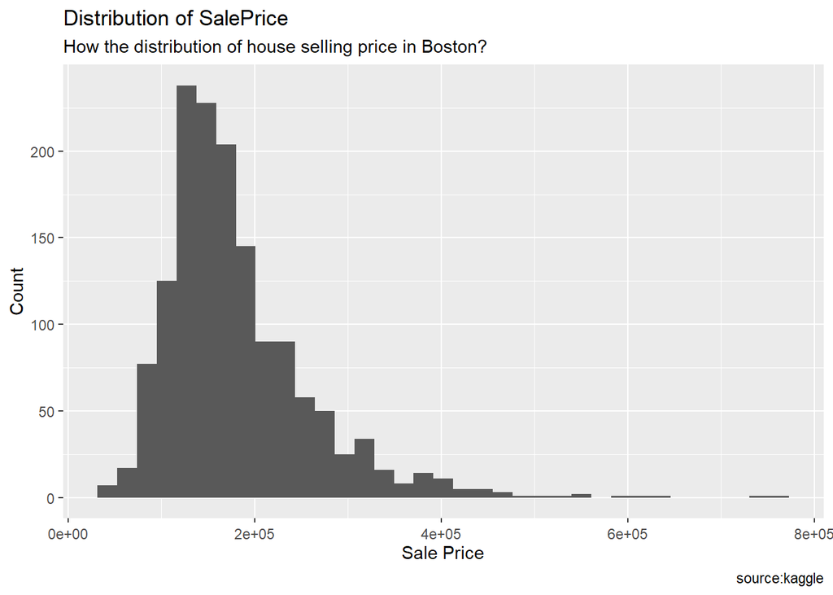

```r
dfori %>% ggplot(aes(x=SalePrice)) + geom_histogram(bins=35) +
  labs(title = "Distribution of SalePrice",
       subtitle = "How the distribution of house selling price in Boston?",
       caption = "source:kaggle",
       x="Sale Price",
       y="Count") +
  theme(axis.text.x = element_text(vjust=0.6))
```

Dari visualisasi diatas, insight yang bisa diambil adalah : Insight 5 : Distribusi dari data SalePrice mengalami skewed right, hal ini dikarenakan harga rata-rata jual rumah (mean, 180921) lebih besar dari harga tengah (median.163000)

# 2. Cari 5 variabel dengan korelasi paling kuat(secara positive ataupun negative) terhadap SalePrice, dan kira-kira apakah hasilnya masuk akal?

# Jawab :

Saya melakukan eksplorasi korelasi dengan menggunakan library(corrplot)

[figure not shown]

```r
dfnum = dfori%>%
  select_if(is.numeric)
corr = round(cor(dfnum),1)
ggcorrplot(corr, hc.order = FALSE, lab = TRUE)
```

Melalui eksplorasi tersebut kita bisa melihat angka korelasi SalePrice terhadap semua kolom, dimana : 1. Angka korelasi 80% (0,8) terdapat di OverallQual Menurut saya ini masuk akal, karena OverallQual adalah kualitas dari keseluruhan rumah sehingga akan sangat mempengaruhi harga jual

2. Angka korelasi 70% (0,7) terdapat di GrLivArea Menurut saya ini juga masuk akal, karena GrLivArea adalah area yang habitual (dapat ditinggali) dari keseluruhan rumah. Hal ini menyebabkan semakin banyak area tinggal maka harga akan berpengaruh.. Akan tetapi ada outlier di GrLivArea yang memerlukan analisis lebih lanjut.
3. Angka korelasi 60% (0,6) terdapat di GarageArea,GarageCars,FullBath,1stFlrSF,TotalBsmtSF Untuk GarageArea, GarageCars, FullBath dan TotalBsmtSF masih masuk akal, karena empat variabel tersebut mempengaruhi area dari rumah, sehingga ketika tiga variabel naik otomatis luas rumah bertambah dan harga jual meningkat. Kemudian variabel X1stFlrSF masih bisa diterima apabila rumah lain yang dijadikan sebagai acuan juga hanya memiliki satu lantai, tapi tidak jika rumah tersebut memiliki variabel 2ndBsmtSF.

# 3. It is never hurt to test basic knowledge.

Ada pandangan bahwa OverallQual rendah memiliki kecenderungan harga yang lebih rendah, dan rumah dengan OverallQual tinggi memiliki kecenderungan harga yang lebih tinggi. Lakukan analisis terhaadp hubungan OverallQual dan SalePrice. # Jawab :

Pertama saya akan membuat dataframe dengan hanya saleprice dan overallqual untuk mempermudah analisa

```r
dfqp = dfnum %>%
  select(c("SalePrice","OverallQual"))
```

Kemudian saya akan membuat analisa boxplot. Saya memilih boxplot dikarenakan data tersebut merupakan category (OverallQual) dan Continuous (SalePrice)

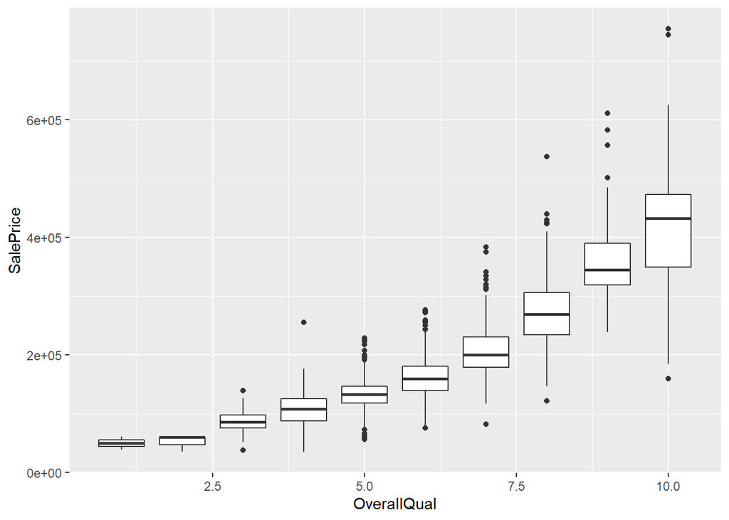

```r
dfqp %>%
  ggplot(aes(x=OverallQual,y=SalePrice,group=OverallQual)) +
  geom_boxplot()
```

# 4. Beware of false correlation

Ada kecenderungan bahwa rumah baru memiliki harga yang lebih tinggi. Akan tetapi, kita tidak boleh gegabah untuk menyimpulkan bahwa rumah baru pasti memiliki harga jual yang lebih tinggi, karena apabila rumah baru yang dibangun tidak baik, tentu harganya juga tidak bisa tinggi. Kira-kira apa hal yang membuat rumah baru memiliki nilai yang lebih tinggi? # Hint : Cek korelasi antara YearBuilt dengan prediktor lainnya # Jawab :

Untuk mempermudah analisa saya akan membuat dataframe dengan berisi hanya YearBuilt,OverallCond,OverallQual,SalePrice.

```r
dfyb = dfnum %>%
  select(c('YearBuilt','OverallCond','OverallQual','SalePrice'))
```

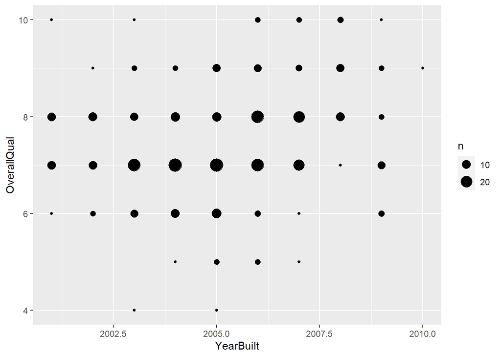

```r
dfyb %>%
  filter(YearBuilt>2000) %>%
  ggplot(aes(YearBuilt,OverallQual)) +
  geom_count()
```

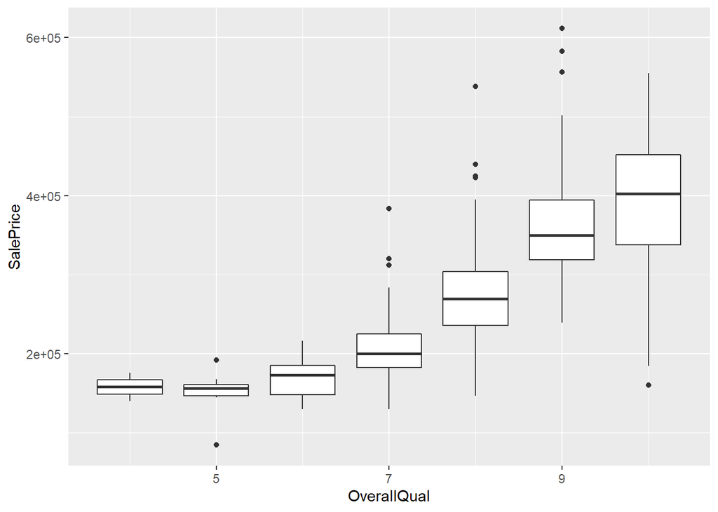

```r
dfyb %>%
  filter(YearBuilt>2000) %>%
  ggplot(aes(OverallQual,SalePrice,group=OverallQual)) +
  geom_boxplot()
```

Kemudian sekarang bandingkan dengan OverallCond terhadap SalePrice, dengan timeframe yang sama.

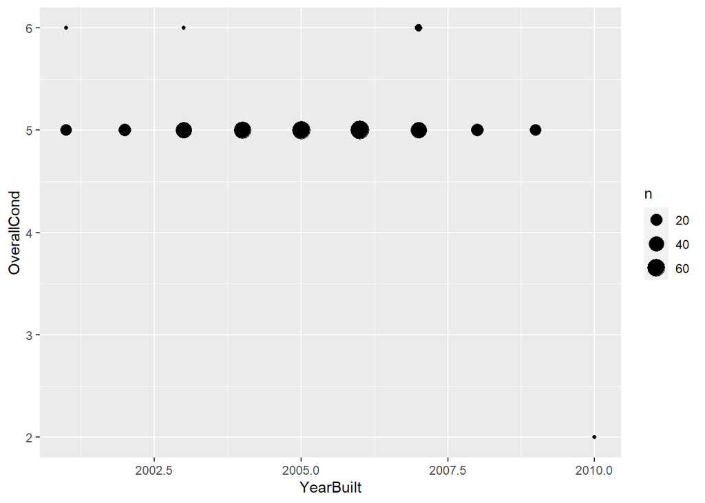

```r
dfyb %>%
  filter(YearBuilt>2000) %>%
  ggplot(aes(YearBuilt,OverallCond)) +
  geom_count()
```

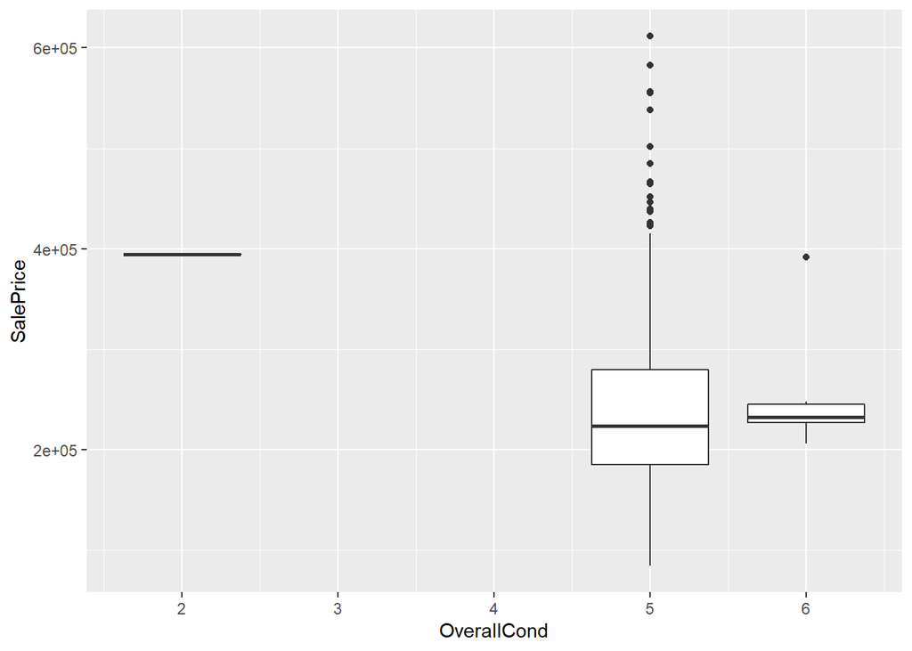

```r
dfyb %>%
  filter(YearBuilt>2000) %>%
  ggplot(aes(OverallCond,SalePrice,group=OverallCond)) +
  geom_boxplot()
```

Jadi kesimpulan saya, memang benar harga rumah baru (SalePrice) lebih tinggi dikarenakan kualitas material dan penyelesaian rumah(OverallQual) dilihat dari korelasi positif 0,8, namun kondisi rumah baru(OverallCond) stuck, bahkan cenderung menurun dilihat dari korelasi negatif 0,1.

# 5. Haunted place(?)

Perhatikan scatter plot berikut

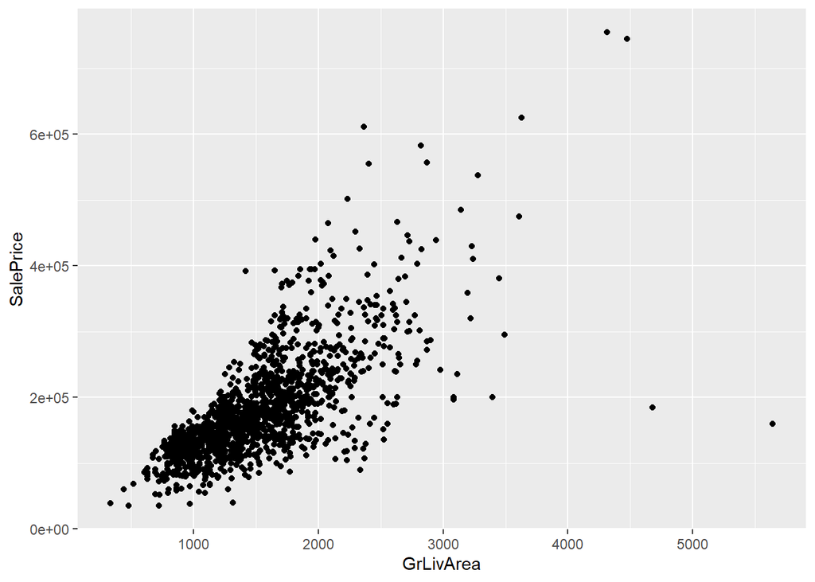

```r
dfori %>% ggplot(aes(x=GrLivArea,y=SalePrice)) + geom_point()
```

Disebelah kanan, ada dua rumah, yang memiliki GreenLivingArea sangat besar, tetapi SalePrice nya murah. Coba analisis kenapa kedua rumah tersebut murah # Jawab :

Pertama, saya akan melakukan filter untuk men-zoom in data yang merupakan dua outlier tersebut. Berdasarkan pengamatan dari scatterplot , dapat dilihat bahwa outlier tersebut merupakan GrLivArea dengan besar lebih dari 4500

```r
dfori %>%
  filter(GrLivArea>4500)
```

```
##     Id MSSubClass MSZoning LotFrontage LotArea Street Alley LotShape
## 1  524         60       RL         130   40094   Pave  <NA>      IR1
## 2 1299         60       RL         313   63887   Pave  <NA>      IR3
##   LandContour Utilities LotConfig LandSlope Neighborhood Condition1 Condition2
## 1         Bnk    AllPub    Inside       Gtl      Edwards       PosN       PosN
## 2         Bnk    AllPub    Corner       Gtl      Edwards      Feedr       Norm
##   BldgType HouseStyle OverallQual OverallCond YearBuilt YearRemodAdd RoofStyle
## 1     1Fam     2Story          10           5      2007         2008       Hip
## 2     1Fam     2Story          10           5      2008         2008       Hip
##   RoofMatl Exterior1st Exterior2nd MasVnrType MasVnrArea ExterQual ExterCond
## 1  CompShg     CemntBd     CmentBd      Stone        762        Ex        TA
## 2  ClyTile      Stucco      Stucco      Stone        796        Ex        TA
##   Foundation BsmtQual BsmtCond BsmtExposure BsmtFinType1 BsmtFinSF1
## 1      PConc       Ex       TA           Gd          GLQ       2260
## 2      PConc       Ex       TA           Gd          GLQ       5644
##   BsmtFinType2 BsmtFinSF2 BsmtUnfSF TotalBsmtSF Heating HeatingQC CentralAir
## 1          Unf          0       878        3138    GasA        Ex          Y
## 2          Unf          0       466        6110    GasA        Ex          Y
##   Electrical X1stFlrSF X2ndFlrSF LowQualFinSF GrLivArea BsmtFullBath
## 1      SBrkr      3138      1538            0      4676            1
## 2      SBrkr      4692       950            0      5642            2
##   BsmtHalfBath FullBath HalfBath BedroomAbvGr KitchenAbvGr KitchenQual
## 1            0        3        1            3            1          Ex
## 2            0        2        1            3            1          Ex
##   TotRmsAbvGrd Functional Fireplaces FireplaceQu GarageType GarageYrBlt
## 1           11        Typ          1          Gd    BuiltIn        2007
## 2           12        Typ          3          Gd     Attchd        2008
##   GarageFinish GarageCars GarageArea GarageQual GarageCond PavedDrive
## 1          Fin          3        884         TA         TA          Y
## 2          Fin          2       1418         TA         TA          Y
##   WoodDeckSF OpenPorchSF EnclosedPorch X3SsnPorch ScreenPorch PoolArea PoolQC
## 1        208         406             0          0           0        0   <NA>
## 2        214         292             0          0           0      480     Gd
##   Fence MiscFeature MiscVal MoSold YrSold SaleType SaleCondition SalePrice
## 1  <NA>        <NA>       0     10   2007      New       Partial    184750
## 2  <NA>        <NA>       0      1   2008      New       Partial    160000
```

Untuk soal ini, saya punya beberapa spekulasi : 1. Karena landcontour.

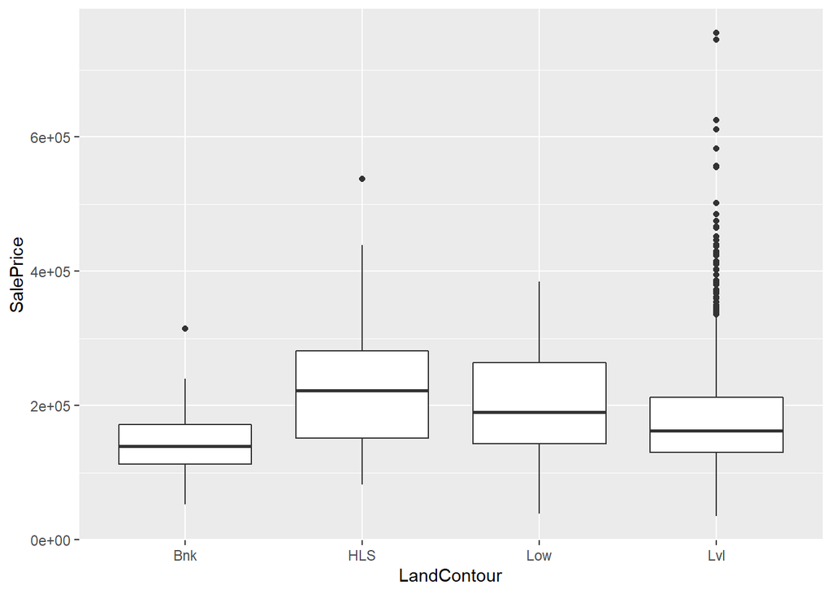

```r
dfori %>%
  ggplot(aes(LandContour,SalePrice,group=LandContour)) +
  geom_boxplot()
```

Berdasarkan analisa boxplot terhadap landcondtour, dapat dilihat bahwa landcountour tipe Bnk memiliki SalePrice yang lebih rendah dari LandContour tipe lain, hal ini diakibatkan karena landcontour struktur tanah yang memiliki kenaikan cepat (dari jalan ke bangunan terlalu curam) sehingga akses keluar dari rumah agak berbahaya.

```
2. Karena bangunan belum selesai pembangunan/remodelling
```

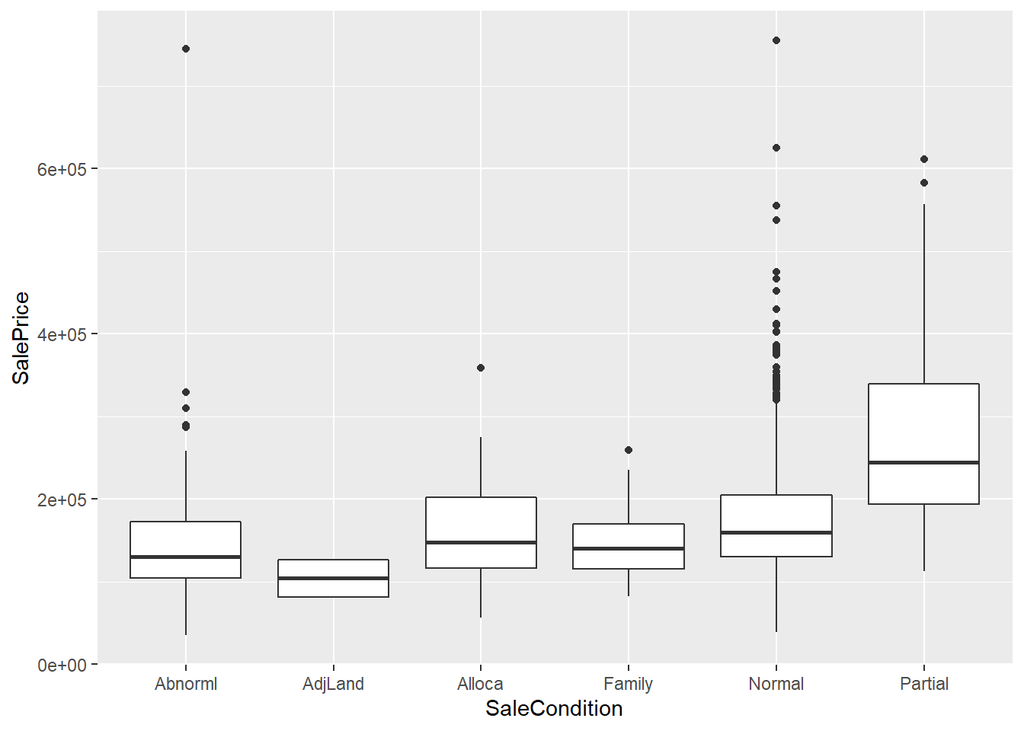

```r
dfori %>%
  ggplot(aes(SaleCondition,SalePrice,group=SaleCondition)) +
  geom_boxplot()
```

3. Great Recession 2007-2009 https://en.wikipedia.org/wiki/Great_Recession#Housing_bubbles Selanjutnya karena Great Recession, pada tahun 2007-2009 terjadi krisis yang diakibatkan oleh housing bubbles yang menyebabkan harga rumah tidak naik maupun turun pada tahun tersebut.

# 6. Freestyle

Lakukan EDA secara bebas dan sampaikan 1 insight yang sekiranya menarik. # Jawab:

Menggunakan pendekatan yang sama dengan nomor 5, saya mencoba menganalisa pengaruh LotArea terhadap SalePrice

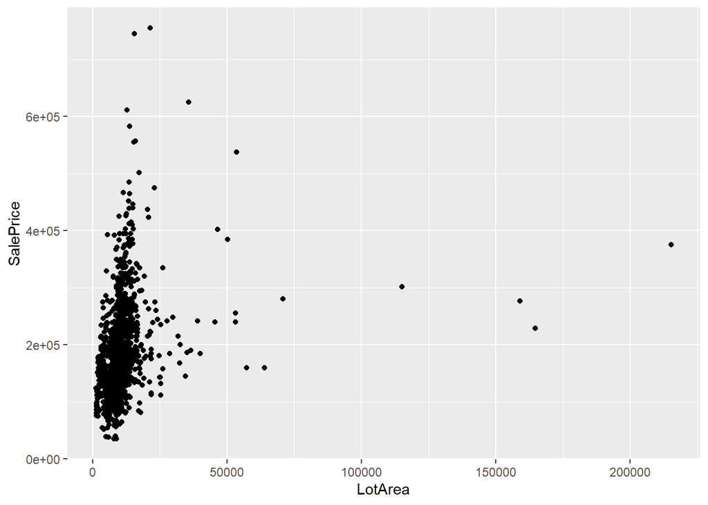

```r
dfori %>%
  ggplot(aes(x=LotArea,y=SalePrice)) + geom_point()
```

Dari scatter plot, terlihat sangat jelas bahwa ada rumah dengan luas yang sangat besar (>200000sqf) namun harganya tidak naik secara signifikan (dilihat dari antara rumah luas 0-50000, ada yang harganya melambung tinggi). Setelah itu saya mencoba melakukan filter terhadap data tersebut.

```r
dfori %>%
  filter(LotArea>200000)
```

```
##    Id MSSubClass MSZoning LotFrontage LotArea Street Alley LotShape LandContour
## 1 314         20       RL         150  215245   Pave  <NA>      IR3         Low
##   Utilities LotConfig LandSlope Neighborhood Condition1 Condition2 BldgType
## 1    AllPub    Inside       Sev       Timber       Norm       Norm     1Fam
##   HouseStyle OverallQual OverallCond YearBuilt YearRemodAdd RoofStyle RoofMatl
## 1     1Story           7           5      1965         1965       Hip  CompShg
##   Exterior1st Exterior2nd MasVnrType MasVnrArea ExterQual ExterCond Foundation
## 1     BrkFace     BrkFace       None          0        TA        TA     CBlock
##   BsmtQual BsmtCond BsmtExposure BsmtFinType1 BsmtFinSF1 BsmtFinType2
## 1       Gd       TA           Gd          ALQ       1236          Rec
##   BsmtFinSF2 BsmtUnfSF TotalBsmtSF Heating HeatingQC CentralAir Electrical
## 1        820        80        2136    GasW        TA          Y      SBrkr
##   X1stFlrSF X2ndFlrSF LowQualFinSF GrLivArea BsmtFullBath BsmtHalfBath FullBath
## 1      2036         0            0      2036            2            0        2
##   HalfBath BedroomAbvGr KitchenAbvGr KitchenQual TotRmsAbvGrd Functional
## 1        0            3            1          TA            8        Typ
##   Fireplaces FireplaceQu GarageType GarageYrBlt GarageFinish GarageCars
## 1          2          Gd     Attchd        1965          RFn          2
##   GarageArea GarageQual GarageCond PavedDrive WoodDeckSF OpenPorchSF
## 1        513         TA         TA          Y          0           0
##   EnclosedPorch X3SsnPorch ScreenPorch PoolArea PoolQC Fence MiscFeature
## 1             0          0           0        0   <NA>  <NA>        <NA>
##   MiscVal MoSold YrSold SaleType SaleCondition SalePrice
## 1       0      6   2009       WD        Normal    375000
```

#Thank you! :)